```python
import this
```

[output not shown]

# Project: The Movie Database Dataset

- Introduction
- Data Wrangling
- Exploratory Data Analysis
- Conclusions

## Introduction

> Different factors relate to the success of a movie. They may range from genre, to cast, to directors The Movie Database is a dataset that holds most of these information for analysis. From the description on Kaggle, 0 values are meant to be taken as null values but I didn't drop them.

> Likely questions to be asked include:
> - What Year had the Highest Revenue?
> - Is There a Relationship Between Budget and Revenue?
> - Do the Cast Influence the Revenue?
> - Do the Directors Influence the Revenue?

## Notebook Imports

```python
import pandas as pd
import numpy as np
import matplotlib.pyplot as matpy
import seaborn as sb

%matplotlib inline
```

```
Matplotlib is building the font cache; this may take a moment.
```

## Data Wrangling

```python
# Importing the dataset
data = pd.read_csv("tmdb-movies.csv")
data.head()
```

|  | id | imdb_id | popularity | budget | revenue | original_title | cast | homepage | director | tagline | ... | overview | runtime | genres | production_companies | release_date | vote_count | vote_average | release_year | budget_adj | revenue_adj |
| --- | --- | --- | --- | --- | --- | --- | --- | --- | --- | --- | --- | --- | --- | --- | --- | --- | --- | --- | --- | --- | --- |
| 0 | 135397 | tt0369610 | 32.985763 | 150000000 | 1513528810 | Jurassic World | Chris Pratt\|Bryce Dallas Howard\|Irrfan Khan\|Vi... | http://www.jurassicworld.com/ | Colin Trevorrow | The park is open. | ... | Twenty-two years after the events of Jurassic ... | 124 | Action\|Adventure\|Science Fiction\|Thriller | Universal Studios\|Amblin Entertainment\|Legenda... | 6/9/15 | 5562 | 6.5 | 2015 | 1.379999e+08 | 1.392446e+09 |
| 1 | 76341 | tt1392190 | 28.419936 | 150000000 | 378436354 | Mad Max: Fury Road | Tom Hardy\|Charlize Theron\|Hugh Keays-Byrne\|Nic... | http://www.madmaxmovie.com/ | George Miller | What a Lovely Day. | ... | An apocalyptic story set in the furthest reach... | 120 | Action\|Adventure\|Science Fiction\|Thriller | Village Roadshow Pictures\|Kennedy Miller Produ... | 5/13/15 | 6185 | 7.1 | 2015 | 1.379999e+08 | 3.481613e+08 |
| 2 | 262500 | tt2908446 | 13.112507 | 110000000 | 295238201 | Insurgent | Shailene Woodley\|Theo James\|Kate Winslet\|Ansel... | http://www.thedivergentseries.movie/#insurgent | Robert Schwentke | One Choice Can Destroy You | ... | Beatrice Prior must confront her inner demons ... | 119 | Adventure\|Science Fiction\|Thriller | Summit Entertainment\|Mandeville Films\|Red Wago... | 3/18/15 | 2480 | 6.3 | 2015 | 1.012000e+08 | 2.716190e+08 |
| 3 | 140607 | tt2488496 | 11.173104 | 200000000 | 2068178225 | Star Wars: The Force Awakens | Harrison Ford\|Mark Hamill\|Carrie Fisher\|Adam D... | http://www.starwars.com/films/star-wars-episod... | J.J. Abrams | Every generation has a story. | ... | Thirty years after defeating the Galactic Empi... | 136 | Action\|Adventure\|Science Fiction\|Fantasy | Lucasfilm\|Truenorth Productions\|Bad Robot | 12/15/15 | 5292 | 7.5 | 2015 | 1.839999e+08 | 1.902723e+09 |
| 4 | 168259 | tt2820852 | 9.335014 | 190000000 | 1506249360 | Furious 7 | Vin Diesel\|Paul Walker\|Jason Statham\|Michelle ... | http://www.furious7.com/ | James Wan | Vengeance Hits Home | ... | Deckard Shaw seeks revenge against Dominic Tor... | 137 | Action\|Crime\|Thriller | Universal Pictures\|Original Film\|Media Rights ... | 4/1/15 | 2947 | 7.3 | 2015 | 1.747999e+08 | 1.385749e+09 |

5 rows × 21 columns

```python
data.shape
```

```
(10866, 21)
```

```python
data.describe()
```

|  | id | popularity | budget | revenue | runtime | vote_count | vote_average | release_year | budget_adj | revenue_adj |
| --- | --- | --- | --- | --- | --- | --- | --- | --- | --- | --- |
| count | 10866.000000 | 10866.000000 | 1.086600e+04 | 1.086600e+04 | 10866.000000 | 10866.000000 | 10866.000000 | 10866.000000 | 1.086600e+04 | 1.086600e+04 |
| mean | 66064.177434 | 0.646441 | 1.462570e+07 | 3.982332e+07 | 102.070863 | 217.389748 | 5.974922 | 2001.322658 | 1.755104e+07 | 5.136436e+07 |
| std | 92130.136561 | 1.000185 | 3.091321e+07 | 1.170035e+08 | 31.381405 | 575.619058 | 0.935142 | 12.812941 | 3.430616e+07 | 1.446325e+08 |
| min | 5.000000 | 0.000065 | 0.000000e+00 | 0.000000e+00 | 0.000000 | 10.000000 | 1.500000 | 1960.000000 | 0.000000e+00 | 0.000000e+00 |
| 25% | 10596.250000 | 0.207583 | 0.000000e+00 | 0.000000e+00 | 90.000000 | 17.000000 | 5.400000 | 1995.000000 | 0.000000e+00 | 0.000000e+00 |
| 50% | 20669.000000 | 0.383856 | 0.000000e+00 | 0.000000e+00 | 99.000000 | 38.000000 | 6.000000 | 2006.000000 | 0.000000e+00 | 0.000000e+00 |
| 75% | 75610.000000 | 0.713817 | 1.500000e+07 | 2.400000e+07 | 111.000000 | 145.750000 | 6.600000 | 2011.000000 | 2.085325e+07 | 3.369710e+07 |
| max | 417859.000000 | 32.985763 | 4.250000e+08 | 2.781506e+09 | 900.000000 | 9767.000000 | 9.200000 | 2015.000000 | 4.250000e+08 | 2.827124e+09 |

```python
data.info()
```

```
<class 'pandas.core.frame.DataFrame'>
RangeIndex: 10866 entries, 0 to 10865
Data columns (total 21 columns):
 #   Column                Non-Null Count  Dtype
---  ------                --------------  -----
 0   id                    10866 non-null  int64
 1   imdb_id               10856 non-null  object
 2   popularity            10866 non-null  float64
 3   budget                10866 non-null  int64
 4   revenue               10866 non-null  int64
 5   original_title        10866 non-null  object
 6   cast                  10790 non-null  object
 7   homepage              2936 non-null   object
 8   director              10822 non-null  object
 9   tagline               8042 non-null   object
 10  keywords              9373 non-null   object
 11  overview              10862 non-null  object
 12  runtime               10866 non-null  int64
 13  genres                10843 non-null  object
 14  production_companies  9836 non-null   object
 15  release_date          10866 non-null  object
 16  vote_count            10866 non-null  int64
 17  vote_average          10866 non-null  float64
 18  release_year          10866 non-null  int64
 19  budget_adj            10866 non-null  float64
 20  revenue_adj           10866 non-null  float64
dtypes: float64(4), int64(6), object(11)
memory usage: 1.7+ MB
```

```python
data.isna().sum()
```

```
id                         0
imdb_id                   10
popularity                 0
budget                     0
revenue                    0
original_title             0
cast                      76
homepage                7930
director                  44
tagline                 2824
keywords                1493
overview                   4
runtime                    0
genres                    23
production_companies    1030
release_date               0
vote_count                 0
vote_average               0
release_year               0
budget_adj                 0
revenue_adj                0
dtype: int64
```

```python
(data == 0).any()
```

```
id                      False
imdb_id                 False
popularity              False
budget                   True
revenue                  True
original_title          False
cast                    False
homepage                False
director                False
tagline                 False
keywords                False
overview                False
runtime                  True
genres                  False
production_companies    False
release_date            False
vote_count              False
vote_average            False
release_year            False
budget_adj               True
revenue_adj              True
dtype: bool
```

**From the above, I noticed that while the data was quite clean, there were still some things that needed fixing.**

> 1. imdb_id
> 2. cast
> 3. director
> 4. keywords
> 5. genres
> 6. production_companies

**And also some unrelated columns needs to be dropped.**

> 1. original_title
> 2. homepage
> 3. tagline
> 4. overview

**I also noticed that there some pieces of data that even though they aren't null, were equal to zero.**

> 1. budget
> 2. revenue
> 3. runtime
> 4. budget_adj
> 5. revenue_adj

## Data Cleaning

**These columns are dropped because I feel they would not be necessary in the exploratory phase.**

```python
# Dropping unnecessary columns
data.drop(["original_title", "homepage", "tagline", "overview"], axis = 1, inplace = True)
data.head()
```

|  | id | imdb_id | popularity | budget | revenue | cast | director | keywords | runtime | genres | production_companies | release_date | vote_count | vote_average | release_year | budget_adj | revenue_adj |
| --- | --- | --- | --- | --- | --- | --- | --- | --- | --- | --- | --- | --- | --- | --- | --- | --- | --- |
| 0 | 135397 | tt0369610 | 32.985763 | 150000000 | 1513528810 | Chris Pratt\|Bryce Dallas Howard\|Irrfan Khan\|Vi... | Colin Trevorrow | monster\|dna\|tyrannosaurus rex\|velociraptor\|island | 124 | Action\|Adventure\|Science Fiction\|Thriller | Universal Studios\|Amblin Entertainment\|Legenda... | 6/9/15 | 5562 | 6.5 | 2015 | 1.379999e+08 | 1.392446e+09 |
| 1 | 76341 | tt1392190 | 28.419936 | 150000000 | 378436354 | Tom Hardy\|Charlize Theron\|Hugh Keays-Byrne\|Nic... | George Miller | future\|chase\|post-apocalyptic\|dystopia\|australia | 120 | Action\|Adventure\|Science Fiction\|Thriller | Village Roadshow Pictures\|Kennedy Miller Produ... | 5/13/15 | 6185 | 7.1 | 2015 | 1.379999e+08 | 3.481613e+08 |
| 2 | 262500 | tt2908446 | 13.112507 | 110000000 | 295238201 | Shailene Woodley\|Theo James\|Kate Winslet\|Ansel... | Robert Schwentke | based on novel\|revolution\|dystopia\|sequel\|dyst... | 119 | Adventure\|Science Fiction\|Thriller | Summit Entertainment\|Mandeville Films\|Red Wago... | 3/18/15 | 2480 | 6.3 | 2015 | 1.012000e+08 | 2.716190e+08 |
| 3 | 140607 | tt2488496 | 11.173104 | 200000000 | 2068178225 | Harrison Ford\|Mark Hamill\|Carrie Fisher\|Adam D... | J.J. Abrams | android\|spaceship\|jedi\|space opera\|3d | 136 | Action\|Adventure\|Science Fiction\|Fantasy | Lucasfilm\|Truenorth Productions\|Bad Robot | 12/15/15 | 5292 | 7.5 | 2015 | 1.839999e+08 | 1.902723e+09 |
| 4 | 168259 | tt2820852 | 9.335014 | 190000000 | 1506249360 | Vin Diesel\|Paul Walker\|Jason Statham\|Michelle ... | James Wan | car race\|speed\|revenge\|suspense\|car | 137 | Action\|Crime\|Thriller | Universal Pictures\|Original Film\|Media Rights ... | 4/1/15 | 2947 | 7.3 | 2015 | 1.747999e+08 | 1.385749e+09 |

**The imdb_id column is one consisting of "unique" fields, so it would be best to drop rows with missing imdb_id's instead of trying to manipulate it.**

```python
data.imdb_id.unique()
```

```
array(['tt0369610', 'tt1392190', 'tt2908446', ..., 'tt0060161',
       'tt0061177', 'tt0060666'], dtype=object)
```

```python
data.imdb_id.nunique()
```

```
10855
```

```python
# Dropping null values based on the imdb_id column
data.dropna(subset = ["imdb_id"], inplace = True)
data.info()
```

```
<class 'pandas.core.frame.DataFrame'>
Int64Index: 10856 entries, 0 to 10865
Data columns (total 17 columns):
 #   Column                Non-Null Count  Dtype
---  ------                --------------  -----
 0   id                    10856 non-null  int64
 1   imdb_id               10856 non-null  object
 2   popularity            10856 non-null  float64
 3   budget                10856 non-null  int64
 4   revenue               10856 non-null  int64
 5   cast                  10780 non-null  object
 6   director              10816 non-null  object
 7   keywords              9369 non-null   object
 8   runtime               10856 non-null  int64
 9   genres                10835 non-null  object
 10  production_companies  9831 non-null   object
 11  release_date          10856 non-null  object
 12  vote_count            10856 non-null  int64
 13  vote_average          10856 non-null  float64
 14  release_year          10856 non-null  int64
 15  budget_adj            10856 non-null  float64
 16  revenue_adj           10856 non-null  float64
dtypes: float64(4), int64(6), object(7)
memory usage: 1.5+ MB
```

**Here I'm seperating the table based on data types so that cleaning the data based on the data type would be easier, efficient and well automated**

```python
# Seperating columns
num = data.select_dtypes(include = [int, float])
text = data.select_dtypes(include = object)
```

```python
num.head()
```

|  | id | popularity | budget | revenue | runtime | vote_count | vote_average | release_year | budget_adj | revenue_adj |
| --- | --- | --- | --- | --- | --- | --- | --- | --- | --- | --- |
| 0 | 135397 | 32.985763 | 150000000 | 1513528810 | 124 | 5562 | 6.5 | 2015 | 1.379999e+08 | 1.392446e+09 |
| 1 | 76341 | 28.419936 | 150000000 | 378436354 | 120 | 6185 | 7.1 | 2015 | 1.379999e+08 | 3.481613e+08 |
| 2 | 262500 | 13.112507 | 110000000 | 295238201 | 119 | 2480 | 6.3 | 2015 | 1.012000e+08 | 2.716190e+08 |
| 3 | 140607 | 11.173104 | 200000000 | 2068178225 | 136 | 5292 | 7.5 | 2015 | 1.839999e+08 | 1.902723e+09 |
| 4 | 168259 | 9.335014 | 190000000 | 1506249360 | 137 | 2947 | 7.3 | 2015 | 1.747999e+08 | 1.385749e+09 |

```python
num.info()
```

```
<class 'pandas.core.frame.DataFrame'>
Int64Index: 10856 entries, 0 to 10865
Data columns (total 10 columns):
 #   Column        Non-Null Count  Dtype
---  ------        --------------  -----
 0   id            10856 non-null  int64
 1   popularity    10856 non-null  float64
 2   budget        10856 non-null  int64
 3   revenue       10856 non-null  int64
 4   runtime       10856 non-null  int64
 5   vote_count    10856 non-null  int64
 6   vote_average  10856 non-null  float64
 7   release_year  10856 non-null  int64
 8   budget_adj    10856 non-null  float64
 9   revenue_adj   10856 non-null  float64
dtypes: float64(4), int64(6)
memory usage: 932.9 KB
```

```python
(num == 0).any()
```

```
id              False
popularity      False
budget           True
revenue          True
runtime          True
vote_count      False
vote_average    False
release_year    False
budget_adj       True
revenue_adj      True
dtype: bool
```

I'm going to replace all zero values with mean of each column

```python
# Replacing all zero values with the mean
for i in num.columns:
    if (num[i] == 0).any() == True:
        num[i].replace(0, num[i].mean(), inplace = True)

(num == 0).any()
```

```
id              False
popularity      False
budget          False
revenue         False
runtime         False
vote_count      False
vote_average    False
release_year    False
budget_adj      False
revenue_adj     False
dtype: bool
```

I'm going to change some data types

```python
text.head()
```

|  | imdb_id | cast | director | keywords | genres | production_companies | release_date |
| --- | --- | --- | --- | --- | --- | --- | --- |
| 0 | tt0369610 | Chris Pratt\|Bryce Dallas Howard\|Irrfan Khan\|Vi... | Colin Trevorrow | monster\|dna\|tyrannosaurus rex\|velociraptor\|island | Action\|Adventure\|Science Fiction\|Thriller | Universal Studios\|Amblin Entertainment\|Legenda... | 6/9/15 |
| 1 | tt1392190 | Tom Hardy\|Charlize Theron\|Hugh Keays-Byrne\|Nic... | George Miller | future\|chase\|post-apocalyptic\|dystopia\|australia | Action\|Adventure\|Science Fiction\|Thriller | Village Roadshow Pictures\|Kennedy Miller Produ... | 5/13/15 |
| 2 | tt2908446 | Shailene Woodley\|Theo James\|Kate Winslet\|Ansel... | Robert Schwentke | based on novel\|revolution\|dystopia\|sequel\|dyst... | Adventure\|Science Fiction\|Thriller | Summit Entertainment\|Mandeville Films\|Red Wago... | 3/18/15 |
| 3 | tt2488496 | Harrison Ford\|Mark Hamill\|Carrie Fisher\|Adam D... | J.J. Abrams | android\|spaceship\|jedi\|space opera\|3d | Action\|Adventure\|Science Fiction\|Fantasy | Lucasfilm\|Truenorth Productions\|Bad Robot | 12/15/15 |
| 4 | tt2820852 | Vin Diesel\|Paul Walker\|Jason Statham\|Michelle ... | James Wan | car race\|speed\|revenge\|suspense\|car | Action\|Crime\|Thriller | Universal Pictures\|Original Film\|Media Rights ... | 4/1/15 |

```python
text.info()
```

```
<class 'pandas.core.frame.DataFrame'>
Int64Index: 10856 entries, 0 to 10865
Data columns (total 7 columns):
 #   Column                Non-Null Count  Dtype
---  ------                --------------  -----
 0   imdb_id               10856 non-null  object
 1   cast                  10780 non-null  object
 2   director              10816 non-null  object
 3   keywords              9369 non-null   object
 4   genres                10835 non-null  object
 5   production_companies  9831 non-null   object
 6   release_date          10856 non-null  object
dtypes: object(7)
memory usage: 678.5+ KB
```

```python
text[text["cast"].isna()]
```

|  | imdb_id | cast | director | keywords | genres | production_companies | release_date |
| --- | --- | --- | --- | --- | --- | --- | --- |
| 371 | tt4661600 | NaN | Sanjay Patel | NaN | Animation | Pixar Animation Studios | 11/25/15 |
| 441 | tt4908644 | NaN | Evgeny Afineevsky | NaN | Documentary | Passion Pictures\|Campbell Grobman Films\|Afinee... | 10/9/15 |
| 465 | tt4393514 | NaN | Adam Curtis | manipulation\|politics\|war\|control\|fear | Documentary | BBC | 1/24/15 |
| 536 | tt3762974 | NaN | David Gelb | mustang\|car\|corporation\|henry ford family\|car ... | Documentary | NaN | 10/8/15 |
| 538 | tt3983674 | NaN | Jennifer Siebel Newsom | feminism\|sexism\|young boy\|gender roles\|misogyny | Documentary | NaN | 1/1/15 |
| ... | ... | ... | ... | ... | ... | ... | ... |
| 9677 | tt0093832 | NaN | John Lasseter | NaN | Animation | Pixar Animation Studios | 8/17/87 |
| 9755 | tt0061402 | NaN | Martin Scorsese | NaN | Drama | NaN | 1/1/68 |
| 10434 | tt0060984 | NaN | David Lynch | student movie\|short | Animation | Pensylvania Academy of Fine Arts | 1/1/67 |
| 10550 | tt0091455 | NaN | John Lasseter | pixar animated short\|luxo lamps\|beach ball\|fat... | Animation\|Family | Pixar Animation Studios | 8/17/86 |
| 10754 | tt0064064 | NaN | Marv Newland | roe | Animation\|Comedy | NaN | 1/1/69 |

76 rows × 7 columns

```python
text.mode(dropna = True)
```

|  | imdb_id | cast | director | keywords | genres | production_companies | release_date |
| --- | --- | --- | --- | --- | --- | --- | --- |
| 0 | tt0411951 | Louis C.K. | Woody Allen | woman director | Drama | Paramount Pictures | 1/1/09 |

```python
text["cast"].mode(dropna = True)[0]
```

```
'Louis C.K.'
```

I'm going to replace all missing values with the mode of each column

```python
# Replacing missing values with the mode
for i in text.columns:
    if data[i].isna().any() == True:
        data[i].fillna(data[i].mode()[0], inplace = True)

text.info()
```

```
<class 'pandas.core.frame.DataFrame'>
Int64Index: 10856 entries, 0 to 10865
Data columns (total 7 columns):
 #   Column                Non-Null Count  Dtype
---  ------                --------------  -----
 0   imdb_id               10856 non-null  object
 1   cast                  10856 non-null  object
 2   director              10856 non-null  object
 3   keywords              10856 non-null  object
 4   genres                10856 non-null  object
 5   production_companies  10856 non-null  object
 6   release_date          10856 non-null  object
dtypes: object(7)
memory usage: 678.5+ KB
```

```python
text.isna().sum()
```

```
imdb_id                 0
cast                    0
director                0
keywords                0
genres                  0
production_companies    0
release_date            0
dtype: int64
```

```python
text.head()
```

|  | imdb_id | cast | director | keywords | genres | production_companies | release_date |
| --- | --- | --- | --- | --- | --- | --- | --- |
| 0 | tt0369610 | Chris Pratt\|Bryce Dallas Howard\|Irrfan Khan\|Vi... | Colin Trevorrow | monster\|dna\|tyrannosaurus rex\|velociraptor\|island | Action\|Adventure\|Science Fiction\|Thriller | Universal Studios\|Amblin Entertainment\|Legenda... | 6/9/15 |
| 1 | tt1392190 | Tom Hardy\|Charlize Theron\|Hugh Keays-Byrne\|Nic... | George Miller | future\|chase\|post-apocalyptic\|dystopia\|australia | Action\|Adventure\|Science Fiction\|Thriller | Village Roadshow Pictures\|Kennedy Miller Produ... | 5/13/15 |
| 2 | tt2908446 | Shailene Woodley\|Theo James\|Kate Winslet\|Ansel... | Robert Schwentke | based on novel\|revolution\|dystopia\|sequel\|dyst... | Adventure\|Science Fiction\|Thriller | Summit Entertainment\|Mandeville Films\|Red Wago... | 3/18/15 |
| 3 | tt2488496 | Harrison Ford\|Mark Hamill\|Carrie Fisher\|Adam D... | J.J. Abrams | android\|spaceship\|jedi\|space opera\|3d | Action\|Adventure\|Science Fiction\|Fantasy | Lucasfilm\|Truenorth Productions\|Bad Robot | 12/15/15 |
| 4 | tt2820852 | Vin Diesel\|Paul Walker\|Jason Statham\|Michelle ... | James Wan | car race\|speed\|revenge\|suspense\|car | Action\|Crime\|Thriller | Universal Pictures\|Original Film\|Media Rights ... | 4/1/15 |

```python
text["cast"] = text["cast"].apply(lambda x: x.replace("|", ", "))
text["keywords"] = text["keywords"].apply(lambda x: x.replace("|", ", "))
text["genres"] = text["genres"].apply(lambda x: x.replace("|", ", "))
text["production_companies"] = text["production_companies"].apply(lambda x: x.replace("|", ", "))
```

```python
text.head()
```

|  | imdb_id | cast | director | keywords | genres | production_companies | release_date |
| --- | --- | --- | --- | --- | --- | --- | --- |
| 0 | tt0369610 | Chris Pratt, Bryce Dallas Howard, Irrfan Khan,... | Colin Trevorrow | monster, dna, tyrannosaurus rex, velociraptor,... | Action, Adventure, Science Fiction, Thriller | Universal Studios, Amblin Entertainment, Legen... | 6/9/15 |
| 1 | tt1392190 | Tom Hardy, Charlize Theron, Hugh Keays-Byrne, ... | George Miller | future, chase, post-apocalyptic, dystopia, aus... | Action, Adventure, Science Fiction, Thriller | Village Roadshow Pictures, Kennedy Miller Prod... | 5/13/15 |
| 2 | tt2908446 | Shailene Woodley, Theo James, Kate Winslet, An... | Robert Schwentke | based on novel, revolution, dystopia, sequel, ... | Adventure, Science Fiction, Thriller | Summit Entertainment, Mandeville Films, Red Wa... | 3/18/15 |
| 3 | tt2488496 | Harrison Ford, Mark Hamill, Carrie Fisher, Ada... | J.J. Abrams | android, spaceship, jedi, space opera, 3d | Action, Adventure, Science Fiction, Fantasy | Lucasfilm, Truenorth Productions, Bad Robot | 12/15/15 |
| 4 | tt2820852 | Vin Diesel, Paul Walker, Jason Statham, Michel... | James Wan | car race, speed, revenge, suspense, car | Action, Crime, Thriller | Universal Pictures, Original Film, Media Right... | 4/1/15 |

```python
df = pd.concat([num, text], axis = 1)
df.head(100)
```

|  | id | popularity | budget | revenue | runtime | vote_count | vote_average | release_year | budget_adj | revenue_adj | imdb_id | cast | director | keywords | genres | production_companies | release_date |
| --- | --- | --- | --- | --- | --- | --- | --- | --- | --- | --- | --- | --- | --- | --- | --- | --- | --- |
| 0 | 135397 | 32.985763 | 1.500000e+08 | 1.513529e+09 | 124.0 | 5562 | 6.5 | 2015 | 1.379999e+08 | 1.392446e+09 | tt0369610 | Chris Pratt, Bryce Dallas Howard, Irrfan Khan,... | Colin Trevorrow | monster, dna, tyrannosaurus rex, velociraptor,... | Action, Adventure, Science Fiction, Thriller | Universal Studios, Amblin Entertainment, Legen... | 6/9/15 |
| 1 | 76341 | 28.419936 | 1.500000e+08 | 3.784364e+08 | 120.0 | 6185 | 7.1 | 2015 | 1.379999e+08 | 3.481613e+08 | tt1392190 | Tom Hardy, Charlize Theron, Hugh Keays-Byrne, ... | George Miller | future, chase, post-apocalyptic, dystopia, aus... | Action, Adventure, Science Fiction, Thriller | Village Roadshow Pictures, Kennedy Miller Prod... | 5/13/15 |
| 2 | 262500 | 13.112507 | 1.100000e+08 | 2.952382e+08 | 119.0 | 2480 | 6.3 | 2015 | 1.012000e+08 | 2.716190e+08 | tt2908446 | Shailene Woodley, Theo James, Kate Winslet, An... | Robert Schwentke | based on novel, revolution, dystopia, sequel, ... | Adventure, Science Fiction, Thriller | Summit Entertainment, Mandeville Films, Red Wa... | 3/18/15 |
| 3 | 140607 | 11.173104 | 2.000000e+08 | 2.068178e+09 | 136.0 | 5292 | 7.5 | 2015 | 1.839999e+08 | 1.902723e+09 | tt2488496 | Harrison Ford, Mark Hamill, Carrie Fisher, Ada... | J.J. Abrams | android, spaceship, jedi, space opera, 3d | Action, Adventure, Science Fiction, Fantasy | Lucasfilm, Truenorth Productions, Bad Robot | 12/15/15 |
| 4 | 168259 | 9.335014 | 1.900000e+08 | 1.506249e+09 | 137.0 | 2947 | 7.3 | 2015 | 1.747999e+08 | 1.385749e+09 | tt2820852 | Vin Diesel, Paul Walker, Jason Statham, Michel... | James Wan | car race, speed, revenge, suspense, car | Action, Crime, Thriller | Universal Pictures, Original Film, Media Right... | 4/1/15 |
| ... | ... | ... | ... | ... | ... | ... | ... | ... | ... | ... | ... | ... | ... | ... | ... | ... | ... |
| 95 | 258509 | 1.841779 | 1.463917e+07 | 2.337556e+08 | 92.0 | 278 | 5.7 | 2015 | 1.756721e+07 | 2.150550e+08 | tt2974918 | Jason Lee, Justin Long, Bella Thorne, Matthew ... | Walt Becker | chipmunk, cgi, talking animal, aftercreditssti... | Adventure, Animation, Comedy, Family | Regency Enterprises, Fox 2000 Pictures, Sunswe... | 12/17/15 |
| 96 | 298382 | 1.823130 | 1.193000e+07 | 1.834000e+07 | 118.0 | 197 | 6.9 | 2015 | 1.097560e+07 | 1.687279e+07 | tt2910904 | Kate Winslet, Liam Hemsworth, Caroline Goodall... | Jocelyn Moorhouse | based on novel, australia, dressmaker, hometow... | Drama | Amazon Studios, Film Art Media, Apollo Media | 10/1/15 |
| 97 | 272693 | 1.758618 | 8.500000e+06 | 4.352863e+07 | 100.0 | 753 | 6.8 | 2015 | 7.819997e+06 | 4.004633e+07 | tt1666801 | Mae Whitman, Robbie Amell, Bella Thorne, Bianc... | Ari Sandel | high school, teenager, popularity, high school... | Romance, Comedy | Wonderland Sound and Vision, CBS Films, Vast E... | 2/20/15 |
| 98 | 283445 | 1.742286 | 1.000000e+07 | 5.288202e+07 | 97.0 | 331 | 5.5 | 2015 | 9.199996e+06 | 4.865144e+07 | tt2752772 | Shannyn Sossamon, James Ransone, Tate Ellingto... | Ciaran Foy | haunted house, sequel, twins | Horror | Alliance Films, Blumhouse Productions, IM Glob... | 8/19/15 |
| 99 | 256961 | 1.735180 | 3.000000e+07 | 1.075972e+08 | 94.0 | 422 | 5.3 | 2015 | 2.759999e+07 | 9.898942e+07 | tt3450650 | Kevin James, Raini Rodriguez, Eduardo VerÃ¡ste... | Andy Fickman | shopping mall, las vegas nevada, security guard | Action, Adventure, Comedy, Family | Columbia Pictures, Happy Madison Productions, ... | 4/16/15 |

100 rows × 17 columns

```python
df.info()
```

```
<class 'pandas.core.frame.DataFrame'>
Int64Index: 10856 entries, 0 to 10865
Data columns (total 17 columns):
 #   Column                Non-Null Count  Dtype
---  ------                --------------  -----
 0   id                    10856 non-null  int64
 1   popularity            10856 non-null  float64
 2   budget                10856 non-null  float64
 3   revenue               10856 non-null  float64
 4   runtime               10856 non-null  float64
 5   vote_count            10856 non-null  int64
 6   vote_average          10856 non-null  float64
 7   release_year          10856 non-null  int64
 8   budget_adj            10856 non-null  float64
 9   revenue_adj           10856 non-null  float64
 10  imdb_id               10856 non-null  object
 11  cast                  10856 non-null  object
 12  director              10856 non-null  object
 13  keywords              10856 non-null  object
 14  genres                10856 non-null  object
 15  production_companies  10856 non-null  object
 16  release_date          10856 non-null  object
dtypes: float64(7), int64(3), object(7)
memory usage: 1.5+ MB
```

I noticed that the data type of runtime changed to float. So I'm going to change it back.

```python
df["runtime"] = df["runtime"].astype("int64")
df.info()
```

```
<class 'pandas.core.frame.DataFrame'>
Int64Index: 10856 entries, 0 to 10865
Data columns (total 17 columns):
 #   Column                Non-Null Count  Dtype
---  ------                --------------  -----
 0   id                    10856 non-null  int64
 1   popularity            10856 non-null  float64
 2   budget                10856 non-null  float64
 3   revenue               10856 non-null  float64
 4   runtime               10856 non-null  int64
 5   vote_count            10856 non-null  int64
 6   vote_average          10856 non-null  float64
 7   release_year          10856 non-null  int64
 8   budget_adj            10856 non-null  float64
 9   revenue_adj           10856 non-null  float64
 10  imdb_id               10856 non-null  object
 11  cast                  10856 non-null  object
 12  director              10856 non-null  object
 13  keywords              10856 non-null  object
 14  genres                10856 non-null  object
 15  production_companies  10856 non-null  object
 16  release_date          10856 non-null  object
dtypes: float64(6), int64(4), object(7)
memory usage: 1.5+ MB
```

```python
df.describe()
```

|  | id | popularity | budget | revenue | runtime | vote_count | vote_average | release_year | budget_adj | revenue_adj |
| --- | --- | --- | --- | --- | --- | --- | --- | --- | --- | --- |
| count | 10856.000000 | 10856.000000 | 1.085600e+04 | 1.085600e+04 | 10856.000000 | 10856.000000 | 10856.000000 | 10856.000000 | 1.085600e+04 | 1.085600e+04 |
| mean | 65957.002487 | 0.646828 | 2.230802e+07 | 6.191225e+07 | 102.395542 | 217.574245 | 5.973775 | 2001.313928 | 2.676992e+07 | 7.985480e+07 |
| std | 92014.290427 | 1.000545 | 2.802173e+07 | 1.110655e+08 | 30.867530 | 575.851931 | 0.934607 | 12.815353 | 3.051776e+07 | 1.366158e+08 |
| min | 5.000000 | 0.000065 | 1.000000e+00 | 2.000000e+00 | 2.000000 | 10.000000 | 1.500000 | 1960.000000 | 9.210911e-01 | 2.370705e+00 |
| 25% | 10591.750000 | 0.207759 | 1.463917e+07 | 3.986000e+07 | 90.000000 | 17.000000 | 5.400000 | 1995.000000 | 1.756721e+07 | 5.141168e+07 |
| 50% | 20619.000000 | 0.384018 | 1.463917e+07 | 3.986000e+07 | 99.000000 | 38.000000 | 6.000000 | 2006.000000 | 1.756721e+07 | 5.141168e+07 |
| 75% | 75369.250000 | 0.714339 | 1.500000e+07 | 3.986000e+07 | 111.000000 | 146.000000 | 6.600000 | 2011.000000 | 2.085887e+07 | 5.141168e+07 |
| max | 417859.000000 | 32.985763 | 4.250000e+08 | 2.781506e+09 | 900.000000 | 9767.000000 | 9.200000 | 2015.000000 | 4.250000e+08 | 2.827124e+09 |

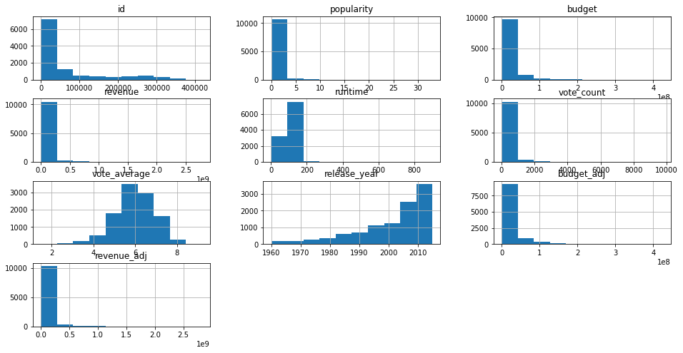

```python
df.hist(figsize = (16, 8));
```

## Exploratory Data Analysis

### Q1: What Year had the Highest Revenue?

```python
df.groupby("release_year")["revenue"].mean()
```

```
release_year
1960    3.567203e+07
1961    3.789614e+07
1962    3.538625e+07
1963    3.716544e+07
1964    4.038624e+07
1965    4.725377e+07
1966    3.736950e+07
1967    4.435487e+07
1968    3.438341e+07
1969    4.130055e+07
1970    4.088542e+07
1971    3.707583e+07
1972    4.226326e+07
1973    4.979384e+07
```

[output cut: 43 more lines]

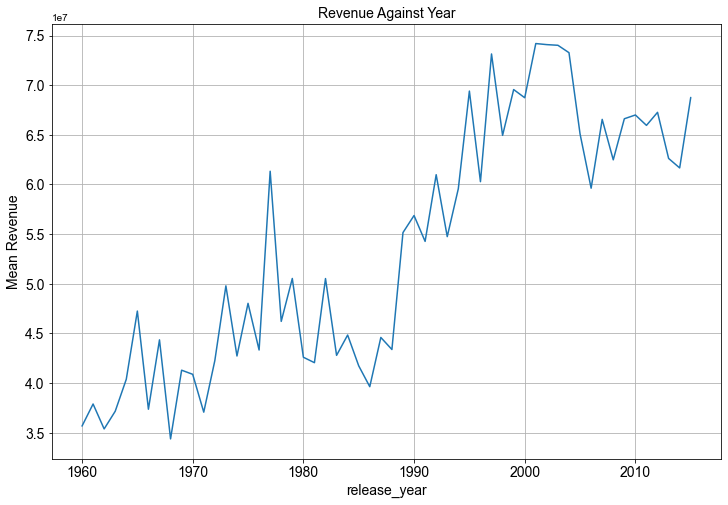

```python
matpy.title("Revenue Against Year", fontsize = 14)

matpy.xlabel("Year", fontsize = 14)
matpy.xticks(fontsize = 14)
matpy.ylabel("Mean Revenue", fontsize = 14)
matpy.yticks(fontsize = 14)
sb.set_style("dark")

df.groupby("release_year")["revenue"].mean().plot(figsize = (12, 8), grid = True);
```

From the above we can observe that between 2000 and 2003, there was a spike in revenue. I also want to check if there is any relationship between the budget and the revenue.

### Q2: Is There a Relationship Between Budget and Revenue?

```python
df[["release_year", "budget", "revenue"]]
```

|  | release_year | budget | revenue |
| --- | --- | --- | --- |
| 0 | 2015 | 1.500000e+08 | 1.513529e+09 |
| 1 | 2015 | 1.500000e+08 | 3.784364e+08 |
| 2 | 2015 | 1.100000e+08 | 2.952382e+08 |
| 3 | 2015 | 2.000000e+08 | 2.068178e+09 |
| 4 | 2015 | 1.900000e+08 | 1.506249e+09 |
| ... | ... | ... | ... |
| 10861 | 1966 | 1.463917e+07 | 3.986000e+07 |
| 10862 | 1966 | 1.463917e+07 | 3.986000e+07 |
| 10863 | 1966 | 1.463917e+07 | 3.986000e+07 |
| 10864 | 1966 | 1.463917e+07 | 3.986000e+07 |
| 10865 | 1966 | 1.900000e+04 | 3.986000e+07 |

10856 rows × 3 columns

```python
budget_revenue = df.groupby("release_year")[["budget", "revenue"]].mean()
budget_revenue
```

| release_year | budget | revenue |
| --- | --- | --- |
| 1960 | 1.121119e+07 | 3.567203e+07 |
| 1961 | 9.988456e+06 | 3.789614e+07 |
| 1962 | 9.944602e+06 | 3.538625e+07 |
| 1963 | 1.205978e+07 | 3.716544e+07 |
| 1964 | 1.174518e+07 | 4.038624e+07 |
| 1965 | 1.204415e+07 | 4.725377e+07 |
| 1966 | 1.207145e+07 | 3.736950e+07 |
| 1967 | 1.056785e+07 | 4.435487e+07 |
| 1968 | 1.085331e+07 | 3.438341e+07 |
| 1969 | 1.127586e+07 | 4.130055e+07 |
| 1970 | 1.238013e+07 | 4.088542e+07 |
| 1971 | 9.899101e+06 | 3.707583e+07 |
| 1972 | 9.324506e+06 | 4.226326e+07 |
| 1973 | 1.103346e+07 | 4.979384e+07 |
| 1974 | 9.735926e+06 | 4.273064e+07 |
| 1975 | 1.126032e+07 | 4.803250e+07 |
| 1976 | 1.194309e+07 | 4.333331e+07 |
| 1977 | 1.053957e+07 | 6.133269e+07 |
| 1978 | 1.177362e+07 | 4.621600e+07 |
| 1979 | 1.294573e+07 | 5.053675e+07 |
| 1980 | 1.346848e+07 | 4.260516e+07 |
| 1981 | 1.169908e+07 | 4.205764e+07 |
| 1982 | 1.371848e+07 | 5.052721e+07 |
| 1983 | 1.380843e+07 | 4.279512e+07 |
| 1984 | 1.405533e+07 | 4.484042e+07 |
| 1985 | 1.412143e+07 | 4.174213e+07 |
| 1986 | 1.320267e+07 | 3.964032e+07 |
| 1987 | 1.375647e+07 | 4.459748e+07 |
| 1988 | 1.425658e+07 | 4.338339e+07 |
| 1989 | 1.546743e+07 | 5.515711e+07 |
| 1990 | 1.764624e+07 | 5.687475e+07 |
| 1991 | 1.894927e+07 | 5.426902e+07 |
| 1992 | 1.832503e+07 | 6.098506e+07 |
| 1993 | 1.731750e+07 | 5.474917e+07 |
| 1994 | 1.999177e+07 | 5.957527e+07 |
| 1995 | 2.315233e+07 | 6.940481e+07 |
| 1996 | 2.417339e+07 | 6.028183e+07 |
| 1997 | 3.053992e+07 | 7.314205e+07 |
| 1998 | 2.839799e+07 | 6.494579e+07 |
| 1999 | 3.063917e+07 | 6.955747e+07 |
| 2000 | 3.069494e+07 | 6.873331e+07 |
| 2001 | 2.930257e+07 | 7.419059e+07 |
| 2002 | 2.766375e+07 | 7.408210e+07 |
| 2003 | 2.887428e+07 | 7.401553e+07 |
| 2004 | 2.926905e+07 | 7.326972e+07 |
| 2005 | 2.648801e+07 | 6.508691e+07 |
| 2006 | 2.497574e+07 | 5.962613e+07 |
| 2007 | 2.466448e+07 | 6.655488e+07 |
| 2008 | 2.339130e+07 | 6.248205e+07 |
| 2009 | 2.393162e+07 | 6.661739e+07 |
| 2010 | 2.661660e+07 | 6.699808e+07 |
| 2011 | 2.380299e+07 | 6.595136e+07 |
| 2012 | 2.286313e+07 | 6.726387e+07 |
| 2013 | 2.264650e+07 | 6.262261e+07 |
| 2014 | 2.103280e+07 | 6.166697e+07 |
| 2015 | 2.184032e+07 | 6.876556e+07 |

```python
df["budget"].corr(df["revenue"])
```

```
0.7053926877213137
```

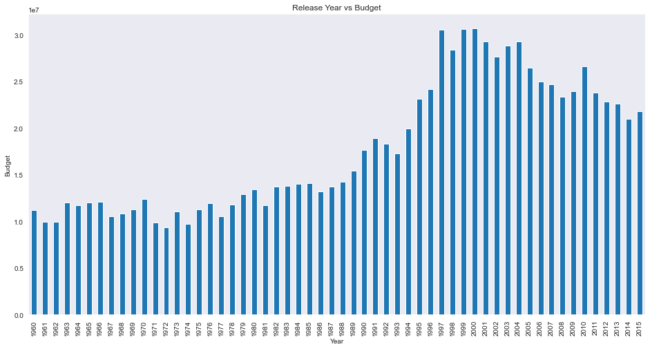

```python
df.groupby("release_year")["budget"].mean().plot(kind = "bar", figsize = (16, 8), title = "Release Year vs Budget",
                                                xlabel = "Year", ylabel = "Budget");
```

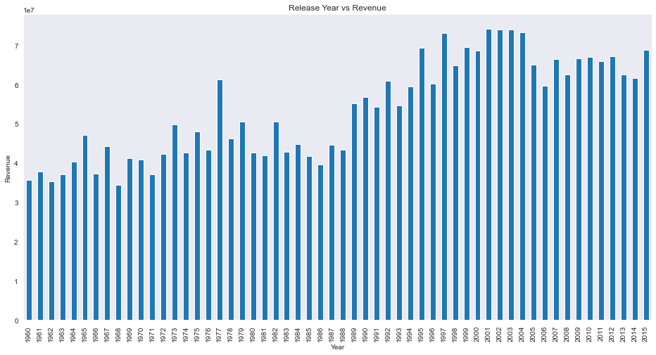

```python
df.groupby("release_year")["revenue"].mean().plot(kind = "bar", figsize = (16, 8), title = "Release Year vs Revenue",
                                                xlabel = "Year", ylabel = "Revenue");
```

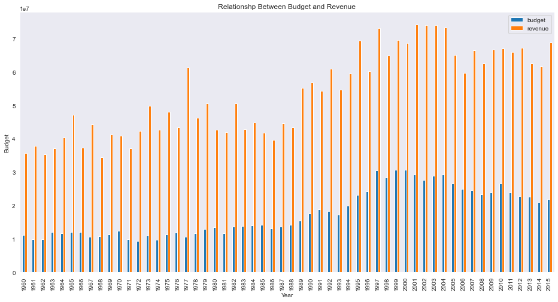

```python
budget_revenue.plot(kind = "bar", figsize = (16, 8), title = "Relationshp Between Budget and Revenue",
                    xlabel = "Year", ylabel = "Budget");
```

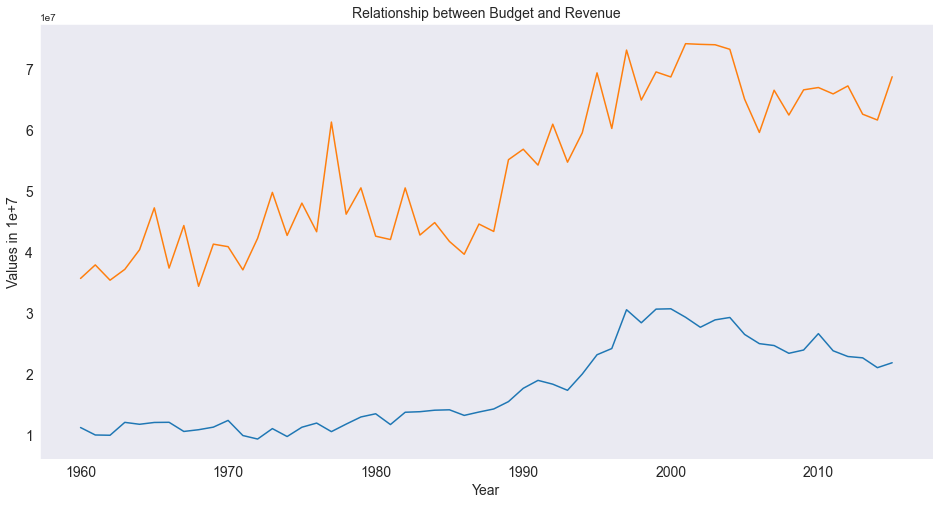

```python
matpy.figure(figsize = (16, 8))
matpy.title("Relationship between Budget and Revenue", fontsize = 14)

matpy.xlabel("Year", fontsize = 14)
matpy.xticks(fontsize = 14)
matpy.ylabel("Values in 1e+7", fontsize = 14)
matpy.yticks(fontsize = 14)

matpy.plot(budget_revenue)
matpy.show()
```

We can clearly see there is a positive correlation between the budget and the revenue.

### Q3: Do the Cast Influence the Revenue?

```python
df.head()
```

|  | id | popularity | budget | revenue | runtime | vote_count | vote_average | release_year | budget_adj | revenue_adj | imdb_id | cast | director | keywords | genres | production_companies | release_date |
| --- | --- | --- | --- | --- | --- | --- | --- | --- | --- | --- | --- | --- | --- | --- | --- | --- | --- |
| 0 | 135397 | 32.985763 | 150000000.0 | 1.513529e+09 | 124 | 5562 | 6.5 | 2015 | 1.379999e+08 | 1.392446e+09 | tt0369610 | Chris Pratt, Bryce Dallas Howard, Irrfan Khan,... | Colin Trevorrow | monster, dna, tyrannosaurus rex, velociraptor,... | Action, Adventure, Science Fiction, Thriller | Universal Studios, Amblin Entertainment, Legen... | 6/9/15 |
| 1 | 76341 | 28.419936 | 150000000.0 | 3.784364e+08 | 120 | 6185 | 7.1 | 2015 | 1.379999e+08 | 3.481613e+08 | tt1392190 | Tom Hardy, Charlize Theron, Hugh Keays-Byrne, ... | George Miller | future, chase, post-apocalyptic, dystopia, aus... | Action, Adventure, Science Fiction, Thriller | Village Roadshow Pictures, Kennedy Miller Prod... | 5/13/15 |
| 2 | 262500 | 13.112507 | 110000000.0 | 2.952382e+08 | 119 | 2480 | 6.3 | 2015 | 1.012000e+08 | 2.716190e+08 | tt2908446 | Shailene Woodley, Theo James, Kate Winslet, An... | Robert Schwentke | based on novel, revolution, dystopia, sequel, ... | Adventure, Science Fiction, Thriller | Summit Entertainment, Mandeville Films, Red Wa... | 3/18/15 |
| 3 | 140607 | 11.173104 | 200000000.0 | 2.068178e+09 | 136 | 5292 | 7.5 | 2015 | 1.839999e+08 | 1.902723e+09 | tt2488496 | Harrison Ford, Mark Hamill, Carrie Fisher, Ada... | J.J. Abrams | android, spaceship, jedi, space opera, 3d | Action, Adventure, Science Fiction, Fantasy | Lucasfilm, Truenorth Productions, Bad Robot | 12/15/15 |
| 4 | 168259 | 9.335014 | 190000000.0 | 1.506249e+09 | 137 | 2947 | 7.3 | 2015 | 1.747999e+08 | 1.385749e+09 | tt2820852 | Vin Diesel, Paul Walker, Jason Statham, Michel... | James Wan | car race, speed, revenge, suspense, car | Action, Crime, Thriller | Universal Pictures, Original Film, Media Right... | 4/1/15 |

```python
cast_df = df[["cast", "revenue"]]
cast_df.head()
```

|  | cast | revenue |
| --- | --- | --- |
| 0 | Chris Pratt, Bryce Dallas Howard, Irrfan Khan,... | 1.513529e+09 |
| 1 | Tom Hardy, Charlize Theron, Hugh Keays-Byrne, ... | 3.784364e+08 |
| 2 | Shailene Woodley, Theo James, Kate Winslet, An... | 2.952382e+08 |
| 3 | Harrison Ford, Mark Hamill, Carrie Fisher, Ada... | 2.068178e+09 |
| 4 | Vin Diesel, Paul Walker, Jason Statham, Michel... | 1.506249e+09 |

```python
cast_df['cast'].value_counts()
```

```
Louis C.K.                                                                              82
William Shatner, Leonard Nimoy, DeForest Kelley, James Doohan, George Takei              5
Bill Burr                                                                                4
Sylvester Stallone, Talia Shire, Burt Young, Carl Weathers, Burgess Meredith             3
Jennifer Lawrence, Josh Hutcherson, Liam Hemsworth, Woody Harrelson, Elizabeth Banks     3
                                                                                        ..
William Hurt, Paul Giamatti, James Woods, Billy Crudup, Topher Grace                     1
Dennis Quaid, Tony Oller, Aimee Teegarden, Stephen Lunsford, Devon Werkheiser            1
Kaya Scodelario, James Northcote, Amy Wren, Nichola Burley, Steve Evets                  1
Toby Kebbell, Brian Cox, Tony Curran, Ashley Bashy Thomas, Tom Brooke                    1
Harold P. Warren, Tom Neyman, John Reynolds, Diane Mahree, Stephanie Nielson             1
Name: cast, Length: 10710, dtype: int64
```

```python
cast_df.groupby("cast")["revenue"].mean()
```

```
cast
"Weird Al" Yankovic, Victoria Jackson, Michael Richards, David Bowe, Fran Drescher                                   3.986000e+07
50 Cent, Forest Whitaker, Robert De Niro, Ryan O'Nan, Matt Gerald                                                    3.986000e+07
50 Cent, Joy Bryant, Adewale Akinnuoye-Agbaje, Omar Benson Miller, Terrence Howard                                   4.644253e+07
50 Cent, Ryan Phillippe, Bruce Willis, James Remar, Randy Couture                                                    3.986000e+07
50 Cent, Tamer Hassan, Danny Dyer, Blake Ritson, EsmÃ© Bianco                                                        3.986000e+07
                                                                                                                         ...
Ã“lafur Darri Ã“lafsson, JÃ³hann G. JÃ³hannsson, Thora Bjorg Helga, TheodÃ³r JÃºlÃusson, MarÃa SigurÃ°ardÃ³ttir    3.986000e+07
Ã“scar Jaenada, Michael Imperioli, Luis Gerardo MÃ©ndez, JoaquÃn Cosio, Teresa Ruiz                                 3.986000e+07
Ã‡etin Tekindor, Fikret Kuskan, Binnur Kaya, Ã–zge Ã–zberk, Tuba Buyukustun                                          3.986000e+07
Ã‰milie Dequenne, LoÃ¯c Corbery, Anne Coesens, Martine Chevalier, Annelise Hesme                                     3.986000e+07
Ã€lex BrendemÃ¼hl, TÃ³mas Lemarquis, Derek de Lint, Irene MontalÃ , FÃ©lix GÃ³mez                                    3.986000e+07
Name: revenue, Length: 10710, dtype: float64
```

```python
cast_list = []
for n in cast_df["cast"].unique():
    v = cast_df[cast_df["cast"] == n]
    cast_list.append(v["revenue"].sum())

sum_revenue = pd.DataFrame(cast_list, columns=["sum_revenue"])
sum_revenue.head()
```

|  | sum_revenue |
| --- | --- |
| 0 | 1.513529e+09 |
| 1 | 3.784364e+08 |
| 2 | 2.952382e+08 |
| 3 | 2.068178e+09 |
| 4 | 1.506249e+09 |

```python
cast_arr = cast_df["cast"].unique()
actors = pd.DataFrame(cast_arr, columns=["actors"])

final_df = pd.concat([actors, sum_revenue], axis =1)
final_df.head(20)
```

|  | actors | sum_revenue |
| --- | --- | --- |
| 0 | Chris Pratt, Bryce Dallas Howard, Irrfan Khan,... | 1.513529e+09 |
| 1 | Tom Hardy, Charlize Theron, Hugh Keays-Byrne, ... | 3.784364e+08 |
| 2 | Shailene Woodley, Theo James, Kate Winslet, An... | 2.952382e+08 |
| 3 | Harrison Ford, Mark Hamill, Carrie Fisher, Ada... | 2.068178e+09 |
| 4 | Vin Diesel, Paul Walker, Jason Statham, Michel... | 1.506249e+09 |
| 5 | Leonardo DiCaprio, Tom Hardy, Will Poulter, Do... | 5.329505e+08 |
| 6 | Arnold Schwarzenegger, Jason Clarke, Emilia Cl... | 4.406035e+08 |
| 7 | Matt Damon, Jessica Chastain, Kristen Wiig, Je... | 5.953803e+08 |
| 8 | Sandra Bullock, Jon Hamm, Michael Keaton, Alli... | 1.156731e+09 |
| 9 | Amy Poehler, Phyllis Smith, Richard Kind, Bill... | 8.537086e+08 |
| 10 | Daniel Craig, Christoph Waltz, LÃ©a Seydoux, R... | 8.806746e+08 |
| 11 | Mila Kunis, Channing Tatum, Sean Bean, Eddie R... | 1.839877e+08 |
| 12 | Domhnall Gleeson, Alicia Vikander, Oscar Isaac... | 3.686941e+07 |
| 13 | Adam Sandler, Michelle Monaghan, Peter Dinklag... | 2.436371e+08 |
| 14 | Robert Downey Jr., Chris Hemsworth, Mark Ruffa... | 1.405036e+09 |
| 15 | Samuel L. Jackson, Kurt Russell, Jennifer Jaso... | 1.557601e+08 |
| 16 | Liam Neeson, Forest Whitaker, Maggie Grace, Fa... | 3.257714e+08 |
| 17 | Paul Rudd, Michael Douglas, Evangeline Lilly, ... | 5.186022e+08 |
| 18 | Lily James, Cate Blanchett, Richard Madden, He... | 5.423514e+08 |
| 19 | Jennifer Lawrence, Josh Hutcherson, Liam Hemsw... | 2.189158e+09 |

```python
# Sortig and storing the first 50 rows for visualization
sorted_final = final_df.sort_values(by = ["sum_revenue"], ascending = False)
f50 = sorted_final.head(50)
```

```python
f50
```

|  | actors | sum_revenue |
| --- | --- | --- |
| 371 | Louis C.K. | 3.065872e+09 |
| 2594 | Elijah Wood, Ian McKellen, Viggo Mortensen, Li... | 2.916545e+09 |
| 1363 | Sam Worthington, Zoe Saldana, Sigourney Weaver... | 2.781506e+09 |
| 19 | Jennifer Lawrence, Josh Hutcherson, Liam Hemsw... | 2.189158e+09 |
| 3 | Harrison Ford, Mark Hamill, Carrie Fisher, Ada... | 2.068178e+09 |
| 625 | Martin Freeman, Ian McKellen, Richard Armitage... | 1.913520e+09 |
| 5151 | Kate Winslet, Leonardo DiCaprio, Frances Fishe... | 1.845034e+09 |
| 6867 | Mike Myers, Eddie Murphy, Cameron Diaz, Julie ... | 1.718797e+09 |
| 4301 | Robert Downey Jr., Chris Evans, Mark Ruffalo, ... | 1.519558e+09 |
| 0 | Chris Pratt, Bryce Dallas Howard, Irrfan Khan,... | 1.513529e+09 |
| 4 | Vin Diesel, Paul Walker, Jason Statham, Michel... | 1.506249e+09 |
| 3860 | Ewan McGregor, Natalie Portman, Hayden Christe... | 1.499398e+09 |
| 1930 | Kristen Stewart, Robert Pattinson, Taylor Laut... | 1.410663e+09 |
| 14 | Robert Downey Jr., Chris Hemsworth, Mark Ruffa... | 1.405036e+09 |
| 3329 | Daniel Radcliffe, Rupert Grint, Emma Watson, A... | 1.327818e+09 |
| 5341 | Kristen Bell, Idina Menzel, Jonathan Groff, Jo... | 1.274219e+09 |
| 5344 | Robert Downey Jr., Gwyneth Paltrow, Guy Pearce... | 1.215440e+09 |
| 8 | Sandra Bullock, Jon Hamm, Michael Keaton, Alli... | 1.156731e+09 |
| 3475 | Shia LaBeouf, John Malkovich, Ken Jeong, Franc... | 1.123747e+09 |
| 7197 | Mark Hamill, Harrison Ford, Carrie Fisher, Bil... | 1.111100e+09 |
| 4305 | Daniel Craig, Judi Dench, Javier Bardem, Ralph... | 1.108561e+09 |
| 7968 | Sandra Bullock, Jeremy Northam, Dennis Miller,... | 1.106280e+09 |
| 4303 | Christian Bale, Michael Caine, Gary Oldman, An... | 1.081041e+09 |
| 6454 | Johnny Depp, Orlando Bloom, Keira Knightley, B... | 1.065660e+09 |
| 1901 | Tom Hanks, Tim Allen, Ned Beatty, Joan Cusack,... | 1.063172e+09 |
| 1892 | Mia Wasikowska, Johnny Depp, Anne Hathaway, He... | 1.025467e+09 |
| 3330 | Johnny Depp, Penélope Cruz, Geoffrey Rush, Ia... | 1.021683e+09 |
| 4307 | Ian McKellen, Martin Freeman, Richard Armitage... | 1.017004e+09 |
| 2836 | Christian Bale, Michael Caine, Heath Ledger, A... | 1.001922e+09 |
| 2595 | Daniel Radcliffe, Rupert Grint, Emma Watson, J... | 9.764756e+08 |
| 5351 | Steve Carell, Kristen Wiig, Benjamin Bratt, Mi... | 9.707619e+08 |
| 7275 | Johnny Depp, Orlando Bloom, Keira Knightley, G... | 9.610000e+08 |
| 1894 | Daniel Radcliffe, Emma Watson, Rupert Grint, R... | 9.543059e+08 |
| 7276 | Daniel Radcliffe, Rupert Grint, Emma Watson, M... | 9.382127e+08 |
| 1366 | Daniel Radcliffe, Rupert Grint, Emma Watson, T... | 9.339592e+08 |
| 2373 | Liam Neeson, Ewan McGregor, Natalie Portman, J... | 9.243176e+08 |
| 10074 | Sam Neill, Laura Dern, Jeff Goldblum, Richard ... | 9.201000e+08 |
| 6093 | Daniel Radcliffe, Rupert Grint, Emma Watson, R... | 8.959210e+08 |
| 7282 | Tobey Maguire, Kirsten Dunst, James Franco, Th... | 8.908716e+08 |
| 1373 | Ray Romano, John Leguizamo, Denis Leary, Queen... | 8.866868e+08 |
| 10 | Daniel Craig, Christoph Waltz, Léa Seydoux, R... | 8.806746e+08 |
| 4315 | John Leguizamo, Ray Romano, Chris Wedge, Denis... | 8.772448e+08 |
| 3855 | Daniel Radcliffe, Rupert Grint, Emma Watson, K... | 8.766885e+08 |
| 4876 | Albert Brooks, Ellen DeGeneres, Alexander Goul... | 8.646260e+08 |
| 9 | Amy Poehler, Phyllis Smith, Richard Kind, Bill... | 8.537086e+08 |
| 1464 | Shia LaBeouf, Megan Fox, Josh Duhamel, Rainn W... | 8.362972e+08 |
| 4352 | Kristen Stewart, Robert Pattinson, Taylor Laut... | 8.290000e+08 |
| 1890 | Leonardo DiCaprio, Joseph Gordon-Levitt, Ellen... | 8.255000e+08 |
| 3859 | Tobey Maguire, Willem Dafoe, Kirsten Dunst, Ja... | 8.217086e+08 |
| 8329 | Will Smith, Bill Pullman, Jeff Goldblum, Mary ... | 8.169693e+08 |

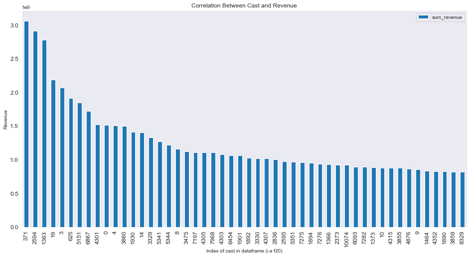

```python
f50.plot(kind = "bar", figsize = (16, 8), fontsize = 12, title = "Correlation Between Cast and Revenue",
        xlabel = "Index of cast in dataframe (i.e f20)", ylabel = "Revenue");
```

Apart from Louis C.K., who was used to fill up null values in the cast column of the dataframe, revenue is higher for some certain actors.

### Q4: Do the Directors Influence the Revenue?

```python
dir_df = df[["director", "revenue"]]
dir_df.head()
```

|  | director | revenue |
| --- | --- | --- |
| 0 | Colin Trevorrow | 1.513529e+09 |
| 1 | George Miller | 3.784364e+08 |
| 2 | Robert Schwentke | 2.952382e+08 |
| 3 | J.J. Abrams | 2.068178e+09 |
| 4 | James Wan | 1.506249e+09 |

```python
dir_df["director"].value_counts()
```

```
Woody Allen         85
Clint Eastwood      34
Martin Scorsese     29
Steven Spielberg    29
Ridley Scott        23
                    ..
Baillie Walsh        1
James Honeyborne     1
Jeff Buhler          1
Gregg Bishop         1
Harold P. Warren     1
Name: director, Length: 5064, dtype: int64
```

```python
dir_df.groupby("director")["revenue"].mean()
```

```
director
 FrÃ©dÃ©ric Jardin            3.358000e+03
A. Todd Smith                 3.986000e+07
A.R. Murugadoss               7.600000e+07
Aaron Aites                   3.986000e+07
Aaron Blaise|Robert Walker    2.500000e+02
                                  ...
Ã‡aÄŸan Irmak                 3.986000e+07
Ã‰mile Gaudreault             3.031801e+06
Ã‰ric Besnard                 3.986000e+07
Ã‰tienne Chatiliez            3.986000e+07
Ã€lex Pastor|David Pastor     5.802422e+06
Name: revenue, Length: 5064, dtype: float64
```

```python
dir_list = []
for n in dir_df["director"].unique():
    v = dir_df[dir_df["director"] == n]
    dir_list.append(v["revenue"].sum())

sum_revenue = pd.DataFrame(dir_list, columns=["sum_revenue"])
sum_revenue.head()
```

|  | sum_revenue |
| --- | --- |
| 0 | 1.517537e+09 |
| 1 | 1.177964e+09 |
| 2 | 7.531688e+08 |
| 3 | 3.579170e+09 |
| 4 | 2.144082e+09 |

```python
arr_dir = dir_df["director"].unique()
directors = pd.DataFrame(arr_dir, columns=["directors"])

final = pd.concat([directors, sum_revenue], axis =1)
final.head(20)
```

|  | directors | sum_revenue |
| --- | --- | --- |
| 0 | Colin Trevorrow | 1.517537e+09 |
| 1 | George Miller | 1.177964e+09 |
| 2 | Robert Schwentke | 7.531688e+08 |
| 3 | J.J. Abrams | 3.579170e+09 |
| 4 | James Wan | 2.144082e+09 |
| 5 | Alejandro González Iñárritu | 8.319236e+08 |
| 6 | Alan Taylor | 9.203685e+08 |
| 7 | Ridley Scott | 3.689856e+09 |
| 8 | Kyle Balda\|Pierre Coffin | 1.156731e+09 |
| 9 | Pete Docter | 8.537086e+08 |
| 10 | Sam Mendes | 2.713549e+09 |
| 11 | Lana Wachowski\|Lilly Wachowski | 2.849448e+08 |
| 12 | Alex Garland | 3.686941e+07 |
| 13 | Chris Columbus | 3.931212e+09 |
| 14 | Joss Whedon | 3.003323e+09 |
| 15 | Quentin Tarantino | 1.606389e+09 |
| 16 | Olivier Megaton | 8.718581e+08 |
| 17 | Peyton Reed | 1.100201e+09 |
| 18 | Kenneth Branagh | 1.386338e+09 |
| 19 | Francis Lawrence | 3.179980e+09 |

```python
sort = final.sort_values(by = ["sum_revenue"], ascending = False)
s20 = sort.head(20)
s20
```

|  | directors | sum_revenue |
| --- | --- | --- |
| 33 | Steven Spielberg | 9.098284e+09 |
| 615 | Peter Jackson | 6.602965e+09 |
| 1272 | James Cameron | 5.921615e+09 |
| 627 | Michael Bay | 4.917208e+09 |
| 611 | Christopher Nolan | 4.247269e+09 |
| 1274 | David Yates | 4.194156e+09 |
| 83 | Robert Zemeckis | 3.949411e+09 |
| 13 | Chris Columbus | 3.931212e+09 |
| 701 | Tim Burton | 3.784995e+09 |
| 7 | Ridley Scott | 3.689856e+09 |
| 66 | Ron Howard | 3.643912e+09 |
| 3 | J.J. Abrams | 3.579170e+09 |
| 2121 | Gore Verbinski | 3.548780e+09 |
| 568 | Roland Emmerich | 3.473046e+09 |
| 1294 | Sam Raimi | 3.353260e+09 |
| 155 | Woody Allen | 3.334345e+09 |
| 1224 | George Lucas | 3.316551e+09 |
| 19 | Francis Lawrence | 3.179980e+09 |
| 634 | Clint Eastwood | 3.143751e+09 |
| 14 | Joss Whedon | 3.003323e+09 |

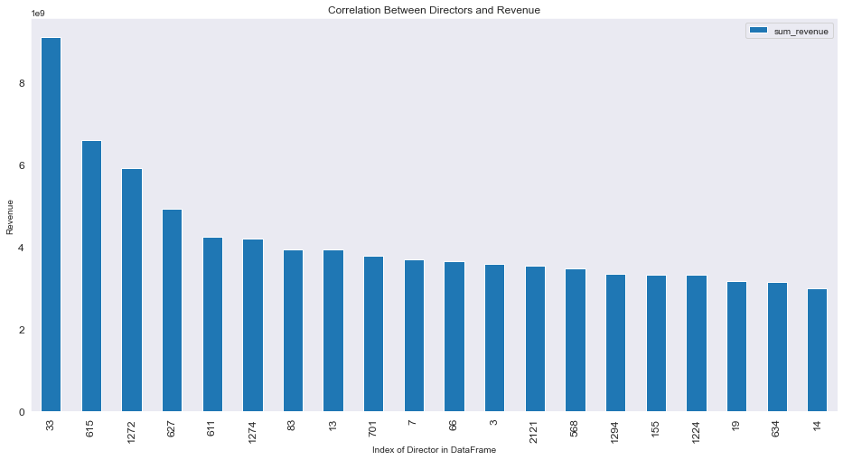

```python
s20.plot(kind = "bar", figsize = (16, 8), fontsize = 12, title = "Correlation Between Directors and Revenue",
        xlabel = "Index of Director in DataFrame", ylabel = "Revenue");
```

## Conclusions

In conclusion, the major factors that influence revenue are as follows:

> Budget: This is likely one of the most important factor (with a correlation of 0.705392687721313)

> Director: As with cast, poularity of the director is influential on the revenue

**Limitations:**

- There were plenty null values and that may have distrupted the cast analysis as they were filled with the mode of the `cast` column.
- Also, zero were a consideration in the `budget` and `revenue` columns. Those were filled with the mean of the respective columns.